# Prediction of Gallstone Disease: A Comprehensive Report

2025-12-3

## Overview

Gallstone is a common disease, and its formation is influenced by multiple factors such as age, gender, obesity, and other health conditions.[1] Non-invasive measures such as body composition offer potential for early detection.[2] Identifying individuals at risk of gallstone disease could enable timely clinical interventions and help reduce complications.[2] The gallstone dataset provides demographic, bioimpedence, and laboratory data that are highly relevant for predicting the presence of gallstones. The primary goal of the project is to identify patients at risk of gallstones using clinical, laboratory, and bioimpedance data before imaging. Additionally, the project aims to assess which markers most reliably signal gallstone risk so that they could be priortized in screening and risk stratification.

## Dataset Description

The gallstone dataset is publicly available through the University of California, Irvine (UCI) Machine Learning Repository (donated on April 19, 2025).[3] Data for this clinical dataset was collected from the Internal Medicine Outpatient Clinic at Ankara VM Medical Park Hospital. The dataset contains records from 319 individuals (June 2022–June 2023), with 161 confirmed cases of gallstone disease.[2] A detailed description of all variables is provided here: https://archive.ics.uci.edu/dataset/1150/gallstone-1

## Methodology

A suite of classification models was developed using repeated 10-fold cross-validation to evaluate predictive performance. The models included Logistic Regression, **Linear Discriminant Analysis (LDA), Quadratic Discriminant Analysis (QDA), K-Nearest Neighbors (KNN), Random Forest, Gradient Boosting Machine (GBM), and Support Vector Machines (SVM)**. Prior to model fitting, data were preprocessed by centering and scaling to ensure comparability across algorithms. All models were trained on the same training subset using standardized tuning and evaluation procedures within the caret framework. Hyperparameter optimization was conducted via grid search. Predictive performance was primarily evaluated using the Area Under the Receiver Operating Characteristic Curve (AUC-ROC), with secondary consideration for accuracy, sensitivity, and specificity. AUC-ROC evaluates model’s ability to discriminate between patients with and without gallstone disease. whereas sensitivity reflects ability to correctly detect gallstone disease, specificity reflects the ability to correctly identify non-disease patients, and accuracy summarizes the overall correct classification rate. Using both a general performance assessment like AUC-ROC and specific, threshold-dependent metrics, such as sensitivity and specificity allows the selection of models based on prioritized clinical needs.

## Results and Interpretation

Table 1: Model performance rankings based on holdout and cross-validation evaluations

| Rank | Model | Holdout_ROC | Holdout_ACC | Holdout_SENS | Holdout_SPEC | CV_ROC | CV_ACC | CV_SENS | CV_SPEC |
| --- | --- | --- | --- | --- | --- | --- | --- | --- | --- |
| 1 | LogReg | 0.907 | 0.841 | 0.875 | 0.806 | 0.827 | 0.778 | 0.844 | 0.712 |
| 2 | svmLinear | 0.903 | 0.825 | 0.906 | 0.742 | 0.840 | 0.778 | 0.849 | 0.706 |
| 3 | RF | 0.867 | 0.810 | 0.812 | 0.806 | 0.860 | 0.783 | 0.807 | 0.759 |
| 4 | GBM | 0.848 | 0.762 | 0.750 | 0.774 | 0.862 | 0.787 | 0.802 | 0.772 |
| 5 | QDA | 0.902 | 0.873 | 0.938 | 0.806 | 0.845 | 0.787 | 0.909 | 0.663 |
| 6 | LDA | 0.892 | 0.825 | 0.844 | 0.806 | 0.792 | 0.740 | 0.839 | 0.638 |
| 7 | svmRadial | 0.856 | 0.730 | 0.688 | 0.774 | 0.818 | 0.766 | 0.803 | 0.738 |
| 8 | KNN | 0.822 | 0.730 | 0.844 | 0.613 | 0.757 | 0.660 | 0.849 | 0.467 |

*ACC = Accuracy, ROC = Area Under the Receiver Operating Characteristic Curve (AUC-ROC), SPEC = Specificity, SENS = Sensitivity* *GBM = Gradient Boosting Machine, KNN = k-Nearest Neighbors, LDA = Linear Discriminant Analysis, LogReg = Logistic Regression, QDA = Quadratic Discriminant Analysis, RF = Random Forest, svmLinear = Support Vector Machine (Linear Kernel), svmRadial = Support Vector Machine (Radial Kernel)*

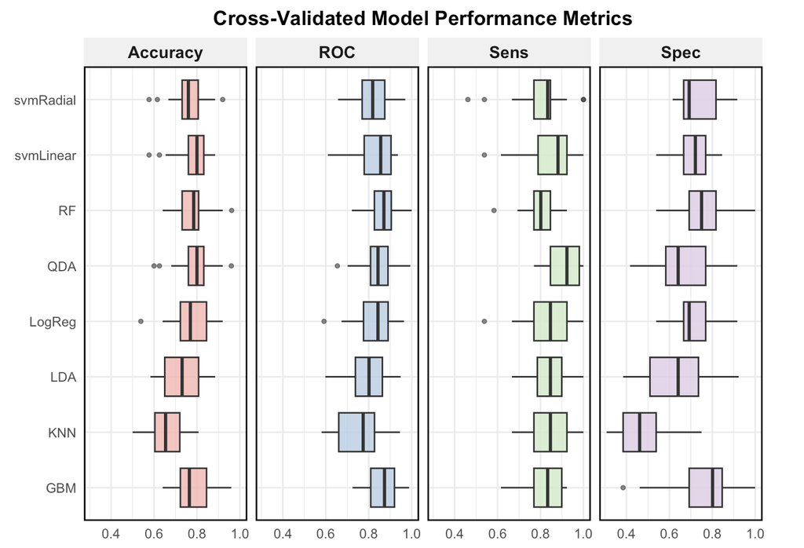

When both the stability of the CV results and the generalizability reflected by the holdout set performance are considered, the logistic regression model stands out as the most reliable choice for predicting gallstone disease in this dataset. It demonstrated strong discrimination, balanced sensitivity and specificity, and consistent performance across both evaluation approaches.

Table 2: Top five predictors ranked by aggregated scaled importance across models

| Variable | LogReg | LDA | svmLinear | RF | GBM | Average |
| --- | --- | --- | --- | --- | --- | --- |
| crp | 100.00 | 27.99 | 100.00 | 100.00 | 100.00 | 85.60 |
| vit_d | 39.33 | 51.86 | 27.64 | 59.34 | 47.97 | 45.23 |
| hfa3 | 82.10 | 100.00 | 14.47 | 3.22 | 6.07 | 41.17 |
| protein | 53.08 | 43.11 | 39.58 | 33.38 | 34.21 | 40.67 |
| ecf_tbw_ratio | 49.17 | 51.89 | 36.78 | 37.26 | 24.66 | 39.95 |

*GBM = Gradient Boosting Machine, LDA = Linear Discriminant Analysis, LogReg = Logistic Regression, RF = Random Forest, svmLinear = Support Vector Machine (Linear Kernel)* *crp = C-reactive protein, vit_d = Vitamin D, hfa = Hepatic Fat Accumulation, protein = Body Protein Content, ecf_tbw_ratio = Extracellular Fluid to Total Body Water Ratio*

## Conclusion

Given its strong generalization, consistency across different evaluations, and inherent transparency and interpretability, logistic regression with lasso regularization is the most appropriate choice for deployment in decision support, where clinicians must understand and trust why a patient is identified as high-risk.

## References

1. Sun H, Warren J, Yip J, et al. Factors Influencing Gallstone Formation: A Review of the Literature. Biomolecules. 2022;12(4). doi:10.3390/biom12040550
2. Esen İ, Arslan H, Aktürk Esen S, Gülşen M, Kültekin N, Özdemir O. Early prediction of gallstone disease with a machine learning-based method from bioimpedance and laboratory data. Medicine (Baltimore). 2024;103(8):e37258. doi:10.1097/MD.0000000000037258
3. Esen İ, Arslan H, Aktürk Esen S, Gülşen M, Kültekin N, Özdemir O. Gallstone [Dataset]. Published online 2024. doi:10.1097/md.0000000000037258.

### Link to the code repository:

https://github.com/linhnslu/gallstone_predictive_analysis/tree/main